# Data Explorations

# Overview

I have downloaded for types of data:

- details about certified personnel
- enrollment numbers both total and by subgroup
- economic status
- Georgia Milestone outcomes

For this data exploration, I’m just going to look at Cobb County School District for 2018. I begin downloading the CPI data using tidyCPI(). This data comes from the the Georgia Governor’s Office of Student Achievement [Downloadable Data](https://gosa.georgia.gov/report-card-dashboards-data/downloadable-data) site. The cleaned-up data is found in the “data/cpi” directory.

I’m going to load the CPI data.

```r
source("getData.R")
options(dplyr.summarise.inform = FALSE)
library(kableExtra)

tidyCPI()
tidyEnrollment()
tidyEconomic()
```

I’m going to create a table for the institutions in Cobb County. I’ll print out a summary as a check.

```r
districtInstitutions <- getDistrictInstitutions("Cobb County")
summary(districtInstitutions)
```

```
 institution_id school_district_id institution_code institution_name
 6330101:  1    633:111            101    :  1      Length:111
 6330102:  1                       102    :  1      Class :character
 6330103:  1                       103    :  1      Mode  :character
 6330104:  1                       104    :  1
 6330107:  1                       107    :  1
 6330109:  1                       109    :  1
 (Other):105                       (Other):105
```

Looks good. Next I’ll load the the average experience table and construct a histogram.

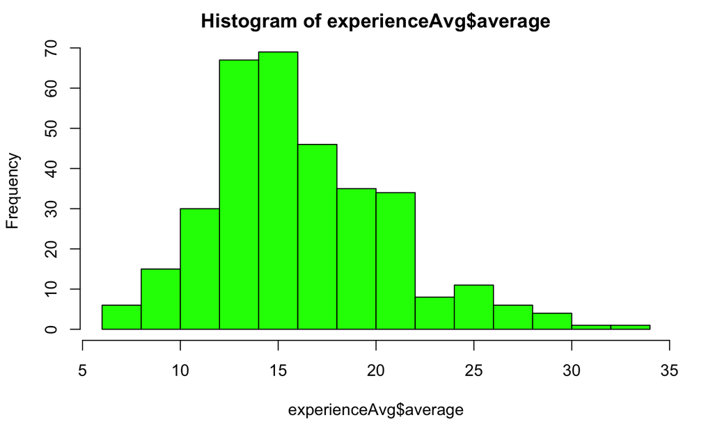

```r
experienceAvg <- merge(read.csv("data/cpi/experienceAvg.csv"), districtInstitutions) %>%
  filter(year=="2018") %>%
  select(institution_id, employee_type, average)
hist(experienceAvg$average, col="green")
```

I’ll do the same thing, but restrict the histogram to teachers.

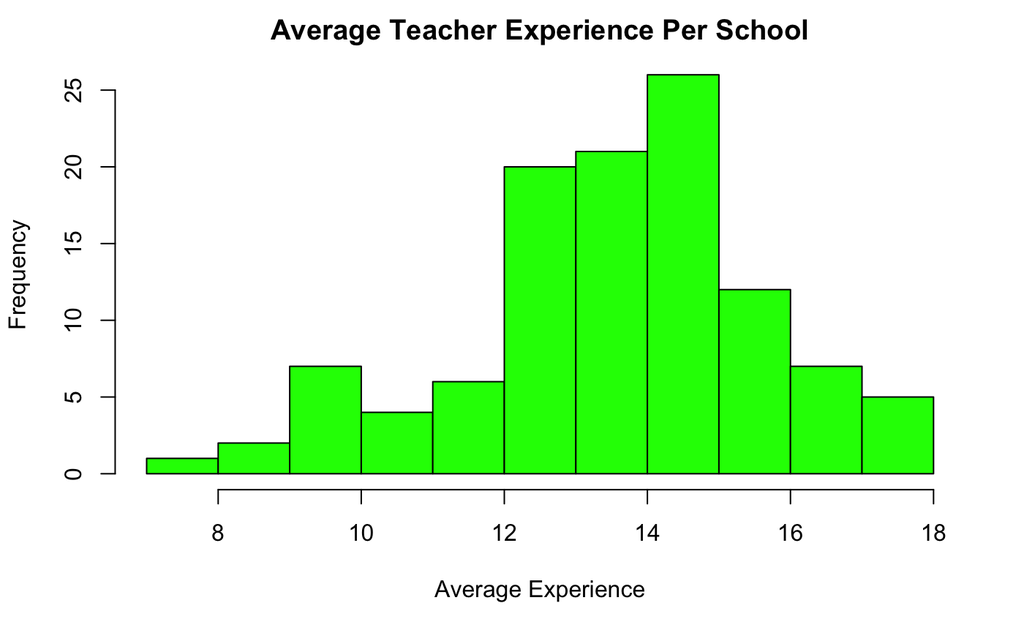

```r
teacherExperienceAvg <- experienceAvg %>%
  filter(employee_type=="PK-12 Teachers") %>%
  select(institution_id, average)
hist(teacherExperienceAvg$average, col="green", main="Average Teacher Experience Per School",
     xlab="Average Experience")
```

The stark difference (nothing above 18) is the result of administrators; they all have a lot of experience. The interesting point here is that some institutions have pretty low average experience for teachers.

Next I’ll load the the salary table and construct a histogram. First for administrators.

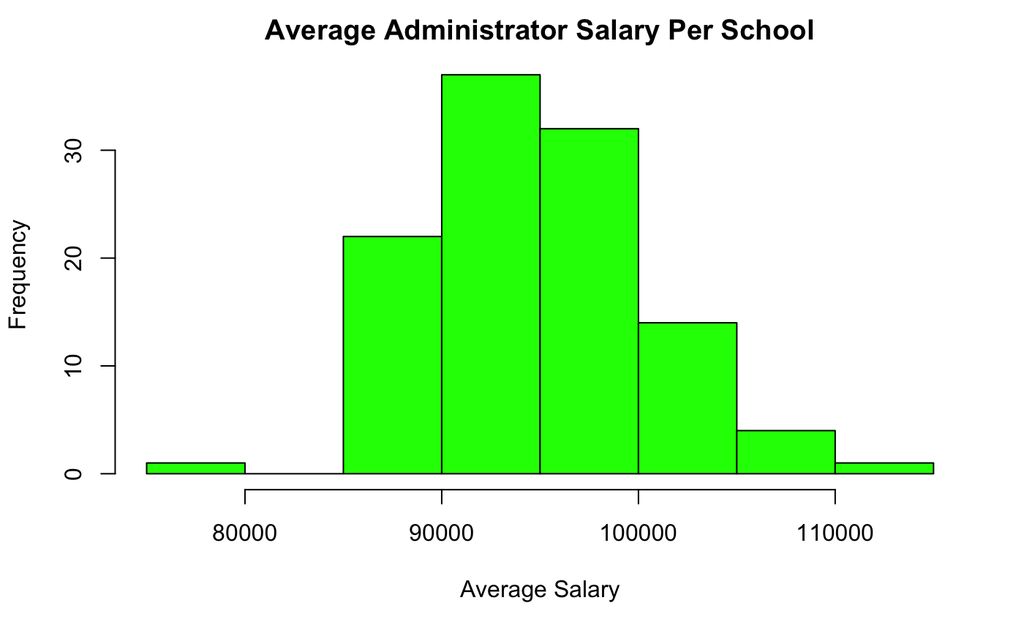

```r
administrators <- merge(read.csv(administratorsDataFile()), districtInstitutions) %>%
  filter(year=="2018")

hist(administrators$avg_annual_salary, col="green", main="Average Administrator Salary Per School",
     xlab="Average Salary")
```

Next, I’ll do the same for teacher salary.

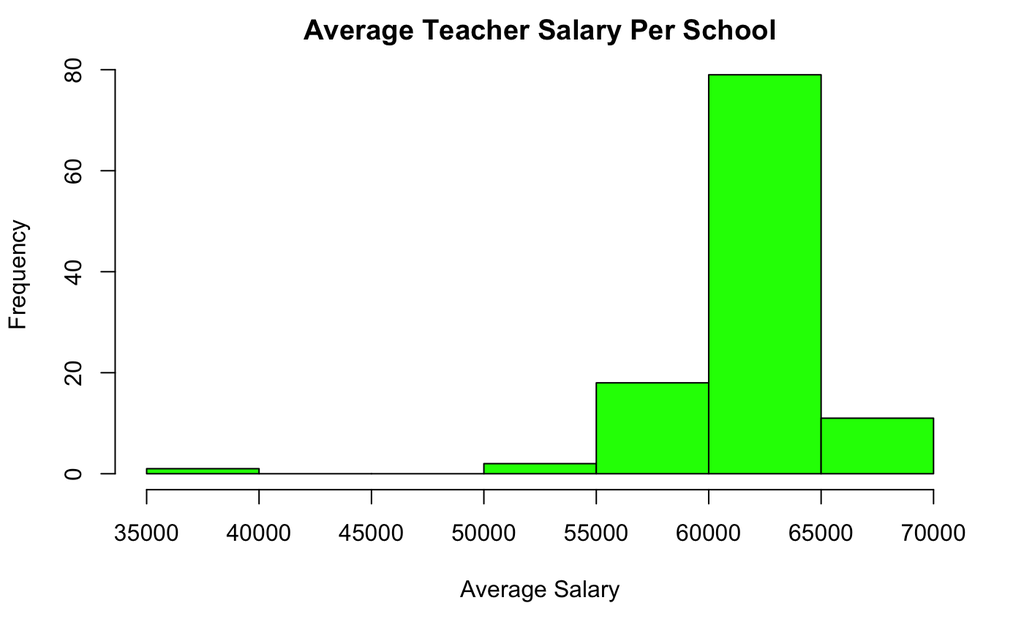

```r
teachers <- merge(read.csv(teachersDataFile()), districtInstitutions) %>%
  filter(year=="2018")

hist(teachers$avg_annual_salary, col="green", main="Average Teacher Salary Per School",
     xlab="Average Salary")
```

There is a low salary school – where is that.

```r
lowSalary <- teachers %>%
  filter(avg_annual_salary < 45000)

lowSalary %>%
  select(institution_name, avg_annual_salary) %>%
  arrange(avg_annual_salary) %>%
  kbl() %>%
  kable_styling()
```

| institution_name | avg_annual_salary |
| --- | --- |
| Kennesaw Charter School | 39451.28 |

```r
NA
NA
```

Next, I’ll do the same for support personnel salary.

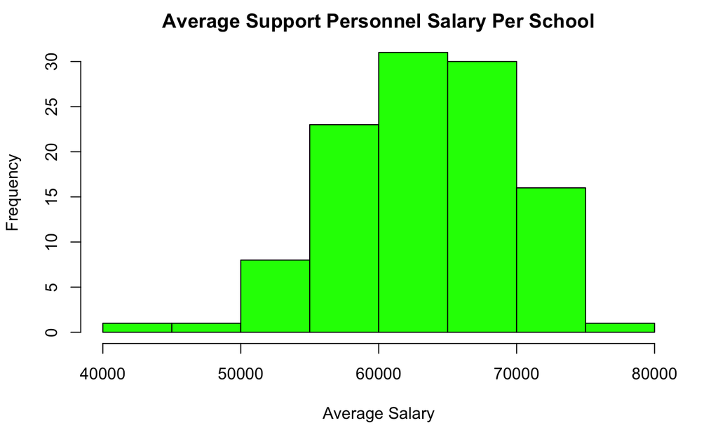

```r
support <- merge(read.csv(supportPersonnelDataFile()), districtInstitutions) %>%
  filter(year=="2018")

hist(support$avg_annual_salary, col="green", main="Average Support Personnel Salary Per School",
     xlab="Average Salary")
```

There are some low salary schools – where are they.

```r
lowSalary <- support %>%
  filter(avg_annual_salary < 50000)

lowSalary %>%
  select(institution_name, avg_annual_salary) %>%
  arrange(avg_annual_salary) %>%
  kbl() %>%
  kable_styling()
```

| institution_name | avg_annual_salary |
| --- | --- |
| Kennesaw Charter School | 40500.0 |
| Baker Elementary School | 49984.1 |

```r
NA
NA
```

Next, I’ll look at enrollment. I’ll at just the fall.

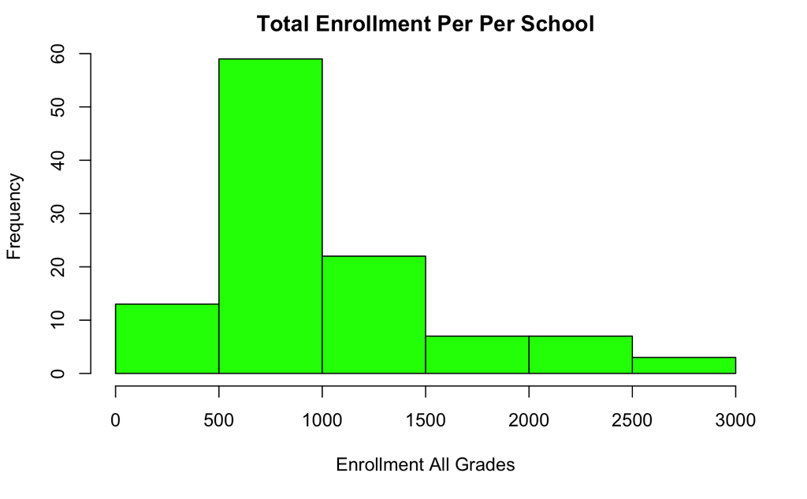

```r
enrollment <- merge(read.csv(enrollmentDataFile()), districtInstitutions) %>%
  filter(year=="2018", period=="Fall") %>%
  group_by(institution_id) %>%
  summarize(total = sum(count))

hist(enrollment$total, col="green", main="Total Enrollment Per Per School",
     xlab="Enrollment All Grades")
```

Next, I’ll look at students per teacher.

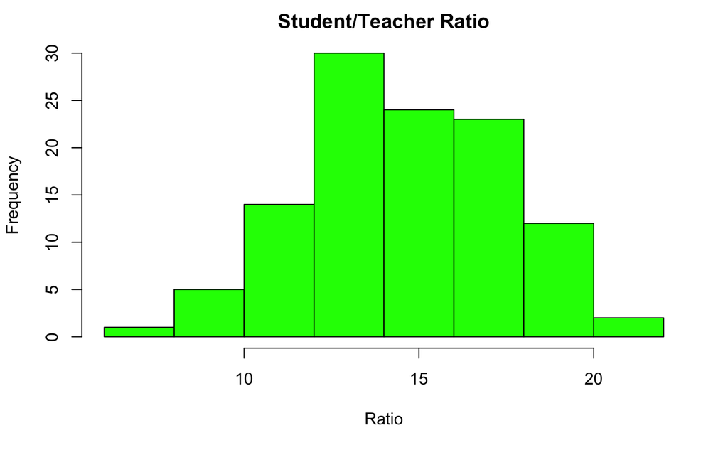

```r
studentTeacherRatio <- merge(enrollment, teachers) %>%
  mutate(ratio=total/count)

hist(studentTeacherRatio$ratio, col="green", main="Student/Teacher Ratio",
    xlab="Ratio")
```

There are some schools with high student teacher ratios.

```r
highStudentTeacherRatio <- studentTeacherRatio %>%
  filter(ratio > 18)

highStudentTeacherRatio %>%
  select(institution_name, ratio) %>%
  arrange(ratio) %>%
  kbl() %>%
  kable_styling()
```

| institution_name | ratio |
| --- | --- |
| Kell High School | 18.01653 |
| Lovinggood Middle School | 18.01917 |
| Dickerson Middle School | 18.10225 |
| Campbell High School | 18.28575 |
| Pope High School | 18.31823 |
| Sprayberry High School | 18.46828 |
| Daniell Middle School | 18.54476 |
| Durham Middle School | 18.82759 |
| North Cobb High School | 19.10541 |
| Walton High School | 19.35414 |
| Allatoona High School | 19.55932 |
| McEachern High School | 19.59177 |
| Hillgrove High School | 20.61174 |
| Harrison High School | 20.89961 |

```r
NA
```

Next, I’ll look at student economic data. These are direct certified percentages.

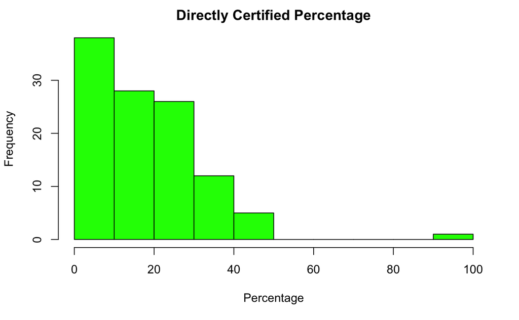

```r
economic <- merge(read.csv(economicDataFile()), districtInstitutions) %>%
  filter(year=="2018")

hist(economic$direct_certified_percent, col="green", main="Directly Certified Percentage",
    xlab="Percentage")
```

```r
highPercent <- economic %>%
  filter(direct_certified_percent > 35)

highPercent %>%
  select(institution_name, percentage=direct_certified_percent) %>%
  arrange(percentage) %>%
  kbl() %>%
  kable_styling()
```

| institution_name | percentage |
| --- | --- |
| Birney Elementary School | 36.1 |
| Clarkdale Elementary School | 37.7 |
| Lindley 6th Grade Academy | 37.9 |
| Garrett Middle School | 38.0 |
| Hendricks Elementary School | 38.8 |
| Austell Elementary School | 38.9 |
| Compton Elementary School | 41.0 |
| Riverside Intermediate School | 41.5 |
| Bryant Elementary School | 41.5 |
| Sanders Elementary School | 41.9 |
| Riverside Primary School | 44.6 |
| Devereux Ackerman Academy | 100.0 |

```r
NA
NA
```

```r
library(kableExtra)

lowExperience <- teacherExperienceAvg %>%
  filter(average < 10.0)

teacherSalary <- merge(lowExperience, read.csv(teachersDataFile()) %>%
  filter(year=="2018") %>%
  select(institution_id, avg_annual_salary, count))

administratorSpend <- merge(lowExperience, read.csv(administratorsDataFile()) %>%
  filter(year=="2018") %>%
  select(institution_id, avg_annual_salary, count)) %>%
  group_by(institution_id) %>%
  summarize(totalAdministratorSpend = avg_annual_salary*count)

supportPersonnelSpend <- merge(lowExperience, read.csv(supportPersonnelDataFile()) %>%
  filter(year=="2018") %>%
  select(institution_id, avg_annual_salary, count)) %>%
  group_by(institution_id) %>%
  summarize(totalSupportSpend = avg_annual_salary*count)

teacherSpend <- teacherSalary %>%
  group_by(institution_id) %>%
  summarize(totalTeacherSpend = avg_annual_salary*count)

spend <- merge(administratorSpend, merge(supportPersonnelSpend, teacherSpend)) %>%
  mutate(totalSpend=totalAdministratorSpend+totalSupportSpend+totalTeacherSpend) %>%
  select(institution_id, totalSpend, totalTeacherSpend)

enrollment <- merge(lowExperience, read.csv(enrollmentDataFile()) %>%
  filter(year=="2018", period=="Fall")) %>%
  group_by(institution_id) %>%
  summarize(total = sum(count))

investmentPerStudent <- merge(spend, enrollment) %>%
  mutate(overall_ips = totalSpend/total, teacher_ips=totalTeacherSpend/total) %>%
  select(institution_id, overall_ips, teacher_ips)

economic <- read.csv(economicDataFile()) %>%
  filter(year=="2018")

merge(merge(merge(merge(lowExperience, districtInstitutions), economic), teacherSalary), investmentPerStudent) %>%
  select(institution_name, direct_certified_percent, average, salary=avg_annual_salary,
         overall_ips, teacher_ips) %>%
  arrange(teacher_ips) %>%
  kbl() %>%
  kable_styling()
```

| institution_name | direct_certified_percent | average | salary | overall_ips | teacher_ips |
| --- | --- | --- | --- | --- | --- |
| Kennesaw Charter School | 15.7 | 7.15 | 39451.28 | 3215.992 | 2964.547 |
| Campbell Middle School | 23.4 | 9.28 | 57247.26 | 3839.798 | 3250.646 |
| Griffin Middle School | 19.8 | 8.85 | 55784.40 | 3929.417 | 3275.908 |
| Mableton Elementary School | 29.5 | 9.78 | 56560.27 | 4915.810 | 4220.016 |
| Hendricks Elementary School | 38.8 | 9.69 | 56791.65 | 5751.580 | 4700.436 |
| Sedalia Park Elementary School | 23.6 | 9.30 | 55733.73 | 6013.308 | 4982.643 |
| Fair Oaks Elementary School | 24.8 | 8.91 | 54323.64 | 6244.043 | 5189.284 |
| Riverside Intermediate School | 41.5 | 9.27 | 56156.17 | 6184.984 | 5273.264 |
| Compton Elementary School | 41.0 | 9.78 | 55572.59 | 6557.320 | 5484.137 |
| Belmont Hills Elementary School | 27.5 | 9.28 | 56241.69 | 7303.890 | 6150.301 |

```r
NA
NA
```

```r
highExperience <- teacherExperienceAvg %>%
  filter(average > 16.0)

teacherSalary <- merge(highExperience, read.csv(teachersDataFile()) %>%
  filter(year=="2018") %>%
  select(institution_id, avg_annual_salary, count))

administratorSpend <- merge(highExperience, read.csv(administratorsDataFile()) %>%
  filter(year=="2018") %>%
  select(institution_id, avg_annual_salary, count)) %>%
  group_by(institution_id) %>%
  summarize(totalAdministratorSpend = avg_annual_salary*count)

supportPersonnelSpend <- merge(highExperience, read.csv(supportPersonnelDataFile()) %>%
  filter(year=="2018") %>%
  select(institution_id, avg_annual_salary, count)) %>%
  group_by(institution_id) %>%
  summarize(totalSupportSpend = avg_annual_salary*count)

teacherSpend <- teacherSalary %>%
  group_by(institution_id) %>%
  summarize(totalTeacherSpend = avg_annual_salary*count)

spend <- merge(administratorSpend, merge(supportPersonnelSpend, teacherSpend)) %>%
  mutate(totalSpend=totalAdministratorSpend+totalSupportSpend+totalTeacherSpend) %>%
  select(institution_id, totalSpend, totalTeacherSpend)

enrollment <- merge(highExperience, read.csv(enrollmentDataFile()) %>%
  filter(year=="2018", period=="Fall")) %>%
  group_by(institution_id) %>%
  summarize(total = sum(count))

investmentPerStudent <- merge(spend, enrollment) %>%
  mutate(overall_ips = totalSpend/total, teacher_ips=totalTeacherSpend/total) %>%
  select(institution_id, overall_ips, teacher_ips)

economic <- read.csv(economicDataFile()) %>%
  filter(year=="2018")

merge(merge(merge(merge(highExperience, districtInstitutions), economic), teacherSalary), investmentPerStudent) %>%
  select(institution_name, direct_certified_percent, average, avg_annual_salary,
         overall_ips, teacher_ips) %>%
  arrange(teacher_ips) %>%
  kbl() %>%
  kable_styling()
```

| institution_name | direct_certified_percent | average | avg_annual_salary | overall_ips | teacher_ips |
| --- | --- | --- | --- | --- | --- |
| Walton High School | 1.6 | 16.21 | 67362.80 | 3953.118 | 3480.537 |
| Dodgen Middle School | 1.4 | 16.03 | 65472.68 | 4198.425 | 3647.241 |
| Lassiter High School | 2.6 | 16.13 | 66261.07 | 4325.928 | 3703.431 |
| Ford Elementary School | 2.2 | 17.13 | 64517.40 | 5014.363 | 4309.290 |
| Pickett's Mill Elementary | 8.2 | 16.46 | 64279.70 | 5211.480 | 4514.024 |
| Due West Elementary School | 4.5 | 17.19 | 63623.52 | 5384.387 | 4595.541 |
| Pitner Elementary School | 18.4 | 17.41 | 65535.30 | 5481.164 | 4695.539 |
| Cheatham Hill Elementary School | 12.9 | 17.23 | 66225.29 | 5513.060 | 4734.670 |
| Kincaid Elementary School | 6.1 | 16.37 | 64527.47 | 5810.181 | 4829.552 |
| Bullard Elementary School | 7.1 | 16.14 | 63862.26 | 5939.618 | 5082.439 |
| Lewis Elementary School | 16.1 | 16.04 | 64168.03 | 6539.467 | 5532.325 |
| Argyle Elementary School | 25.5 | 17.17 | 66152.65 | 8783.954 | 7671.844 |

```r
NA
```

```r
midExperience <- teacherExperienceAvg %>%
  filter(average > 10.0, average < 15)

teacherSalary <- merge(midExperience, read.csv(teachersDataFile()) %>%
  filter(year=="2018") %>%
  select(institution_id, avg_annual_salary, count))

administratorSpend <- merge(midExperience, read.csv(administratorsDataFile()) %>%
  filter(year=="2018") %>%
  select(institution_id, avg_annual_salary, count)) %>%
  group_by(institution_id) %>%
  summarize(totalAdministratorSpend = avg_annual_salary*count)

supportPersonnelSpend <- merge(midExperience, read.csv(supportPersonnelDataFile()) %>%
  filter(year=="2018") %>%
  select(institution_id, avg_annual_salary, count)) %>%
  group_by(institution_id) %>%
  summarize(totalSupportSpend = avg_annual_salary*count)

teacherSpend <- teacherSalary %>%
  group_by(institution_id) %>%
  summarize(totalTeacherSpend = avg_annual_salary*count)

spend <- merge(administratorSpend, merge(supportPersonnelSpend, teacherSpend)) %>%
  mutate(totalSpend=totalAdministratorSpend+totalSupportSpend+totalTeacherSpend) %>%
  select(institution_id, totalSpend, totalTeacherSpend)

enrollment <- merge(midExperience, read.csv(enrollmentDataFile()) %>%
  filter(year=="2018", period=="Fall")) %>%
  group_by(institution_id) %>%
  summarize(total = sum(count))

investmentPerStudent <- merge(spend, enrollment) %>%
  mutate(overall_ips = totalSpend/total, teacher_ips=totalTeacherSpend/total) %>%
  select(institution_id, overall_ips, teacher_ips)

economic <- read.csv(economicDataFile()) %>%
  filter(year=="2018")

merge(merge(merge(merge(midExperience, districtInstitutions), economic), teacherSalary), investmentPerStudent) %>%
  select(institution_name, direct_certified_percent, average, salary=avg_annual_salary,
         overall_ips, teacher_ips) %>%
  arrange(teacher_ips) %>%
  kbl() %>%
  kable_styling()
```

| institution_name | direct_certified_percent | average | salary | overall_ips | teacher_ips |
| --- | --- | --- | --- | --- | --- |
| Harrison High School | 2.8 | 14.88 | 64545.99 | 3544.351 | 3088.382 |
| Hillgrove High School | 5.7 | 14.46 | 65571.11 | 3777.571 | 3181.251 |
| Durham Middle School | 3.4 | 12.97 | 61947.16 | 3792.933 | 3290.234 |
| McEachern High School | 20.4 | 14.09 | 64628.33 | 3855.139 | 3298.749 |
| Daniell Middle School | 15.7 | 14.10 | 61630.94 | 3855.899 | 3323.361 |
| North Cobb High School | 12.1 | 14.03 | 63579.84 | 3780.893 | 3327.844 |
| Cooper Middle School | 28.6 | 10.02 | 58215.50 | 3934.540 | 3377.821 |
| Lindley Middle School | 33.9 | 10.18 | 57488.22 | 4115.823 | 3381.324 |
| Campbell High School | 16.7 | 12.55 | 62494.19 | 3893.581 | 3417.644 |
| Sprayberry High School | 10.6 | 13.65 | 63177.15 | 3950.155 | 3420.846 |
| Kell High School | 10.2 | 13.03 | 61741.89 | 4002.809 | 3426.958 |
| Garrett Middle School | 38.0 | 11.07 | 58688.84 | 4129.506 | 3463.831 |
| Lindley 6th Grade Academy | 37.9 | 12.18 | 61492.49 | 4513.708 | 3472.998 |
| Dickerson Middle School | 1.4 | 14.61 | 63702.53 | 3980.828 | 3519.039 |
| Wheeler High School | 13.7 | 12.26 | 61994.86 | 4091.654 | 3523.799 |
| East Cobb Middle School | 21.5 | 13.63 | 63195.85 | 4170.840 | 3527.698 |
| Pebblebrook High School | 26.6 | 11.22 | 61761.21 | 4228.841 | 3551.890 |
| Lovinggood Middle School | 8.6 | 14.93 | 64467.75 | 4089.781 | 3577.732 |
| Osborne High School | 20.9 | 11.94 | 60905.96 | 4381.989 | 3610.031 |
| Tapp Middle School | 24.5 | 13.25 | 62784.53 | 4293.258 | 3615.658 |
| Bells Ferry Elementary School | 13.3 | 14.46 | 61618.42 | 4390.050 | 3686.495 |
| Pine Mountain Middle School | 18.1 | 11.76 | 60513.83 | 4561.854 | 3750.807 |
| South Cobb High School | 25.4 | 12.42 | 63715.41 | 4533.665 | 3764.006 |
| Barber Middle School | 16.2 | 12.79 | 62202.09 | 4514.704 | 3801.087 |
| Palmer Middle School | 12.6 | 13.67 | 61961.54 | 4485.428 | 3806.702 |
| Mount Bethel Elementary School | 0.7 | 13.88 | 61788.94 | 4394.417 | 3848.268 |
| East Side Elementary School | 0.9 | 12.90 | 61159.85 | 4432.002 | 3852.821 |
| Floyd Middle School | 27.7 | 11.02 | 60122.81 | 4771.903 | 3855.868 |
| Smitha Middle School | 26.9 | 12.49 | 60910.44 | 4683.808 | 3878.570 |
| Simpson Middle School | 3.8 | 14.98 | 64011.71 | 4528.745 | 3937.217 |
| Awtrey Middle School | 10.8 | 13.80 | 60975.09 | 4597.790 | 3959.152 |
| King Springs Elementary School | 9.5 | 14.03 | 61128.38 | 4530.404 | 3968.582 |
| Murdock Elementary School | 4.1 | 13.12 | 61375.82 | 4562.901 | 3991.970 |
| Rocky Mount Elementary School | 2.6 | 12.23 | 61181.71 | 4992.000 | 4022.327 |
| McClure Middle School | 6.6 | 14.89 | 64331.51 | 4517.962 | 4025.759 |
| McCleskey Middle School | 12.8 | 13.63 | 62420.11 | 4870.508 | 4030.842 |
| Sope Creek Elementary School | 3.2 | 12.80 | 59876.04 | 4659.605 | 4052.745 |
| Kennesaw Mountain High School | 8.7 | 14.45 | 65805.14 | 4748.149 | 4153.451 |
| Mountain View Elementary School | 3.3 | 12.09 | 61585.44 | 4936.968 | 4186.596 |
| Teasley Elementary School | 13.3 | 11.90 | 60242.61 | 4831.252 | 4200.630 |
| Davis Elementary School | 3.0 | 12.40 | 60410.57 | 4982.180 | 4215.844 |
| Nickajack Elementary School | 19.6 | 12.54 | 60735.85 | 4815.241 | 4231.157 |
| Smyrna Elementary School | 25.2 | 13.71 | 60138.07 | 4993.022 | 4290.933 |
| Frey Elementary School | 8.0 | 14.81 | 63039.91 | 4988.896 | 4343.623 |
| Hayes Elementary School | 19.1 | 14.31 | 63681.84 | 5267.645 | 4360.211 |
| Acworth Intermediate School | 25.0 | 12.92 | 58720.71 | 5134.132 | 4395.210 |
| Powder Springs Elementary School | 33.4 | 12.69 | 59597.42 | 5220.084 | 4434.605 |
| Varner Elementary School | 24.7 | 14.27 | 61490.73 | 5331.556 | 4501.886 |
| Dowell Elementary School | 23.1 | 13.84 | 62288.60 | 5285.262 | 4531.703 |
| Bryant Elementary School | 41.5 | 10.66 | 59247.14 | 5346.475 | 4543.676 |
| Eastvalley Elementary School | 10.8 | 12.64 | 60804.67 | 5319.267 | 4613.150 |
| Clarkdale Elementary School | 37.7 | 10.23 | 56374.82 | 5706.656 | 4615.736 |
| Keheley Elementary School | 9.7 | 14.22 | 63785.21 | 5475.594 | 4724.340 |
| Addison Elementary School | 11.5 | 13.87 | 63087.38 | 5498.842 | 4735.860 |
| Kennesaw Elementary School | 17.2 | 12.65 | 60574.72 | 5753.910 | 4759.297 |
| Sanders Elementary School | 41.9 | 13.72 | 62404.23 | 5667.123 | 4776.598 |
| Baker Elementary School | 14.3 | 14.00 | 62162.09 | 5483.346 | 4777.030 |
| Shallowford Falls Elementary School | 3.3 | 14.30 | 61620.39 | 5620.602 | 4823.083 |
| Timber Ridge Elementary School | 0.5 | 14.49 | 63797.11 | 5539.135 | 4867.045 |
| Brumby Elementary School | 26.4 | 13.49 | 60968.45 | 5816.683 | 4998.367 |
| Norton Park Elementary School | 28.4 | 13.21 | 60567.99 | 5744.097 | 5010.953 |
| Blackwell Elementary School | 12.1 | 14.71 | 62122.05 | 5938.429 | 5026.583 |
| Austell Elementary School | 38.9 | 14.10 | 62318.89 | 6122.173 | 5027.509 |
| Harmony-Leland Elementary School | 31.4 | 13.92 | 62327.32 | 5936.415 | 5087.285 |
| Russell Elementary School | 24.3 | 12.96 | 60478.50 | 5932.870 | 5186.667 |
| Powers Ferry Elementary School | 30.3 | 12.75 | 59286.77 | 6520.316 | 5431.797 |
| Nicholson Elementary School | 13.2 | 14.07 | 62137.23 | 6351.900 | 5440.285 |
| Still Elementary School | 7.9 | 14.92 | 64776.25 | 6341.965 | 5533.122 |
| Hollydale Elementary School | 33.6 | 12.25 | 59145.84 | 6360.617 | 5783.583 |
| Riverside Primary School | 44.6 | 13.31 | 61714.03 | 6988.597 | 5952.731 |
| Green Acres Elementary School | 22.5 | 13.76 | 63640.88 | 7107.317 | 6104.694 |
| Clay Elementary School | 34.7 | 14.47 | 64374.00 | 7129.907 | 6259.817 |
| McCall Primary School | 24.3 | 14.31 | 60367.78 | 7735.476 | 6336.707 |
| Milford Elementary School | 25.1 | 13.70 | 64088.80 | 7683.991 | 6675.917 |
| LaBelle Elementary School | 25.7 | 14.24 | 63524.45 | 8247.333 | 7011.874 |
| Devereux Ackerman Academy | 100.0 | 13.42 | 54508.04 | 11639.639 | 7637.693 |

```r
NA
```